# Dataset 2

Clustering MS/MS data requires some quality control that can be done in R.

In addition, we will need to use a `bash` script that calls multiple Python scripts. All scripts are available in `bin/`. This notebook explains how the data from the manuscript was clustered.

First, let’s load all required R libraries. We included an `renv` lockfile that describes the package versions we used for this manuscript.

```r
library(renv) #remotes::install_github("rstudio/renv")
renv::restore()
```

```
This project has not yet been activated.
Activating this project will ensure the project library is used during restore.
Please see `?renv::activate` for more details.
```

```r
y
```

[output not shown]

```r
library(tidyverse)
library(stringr)
library(DESeq2)
library(data.table)
library(dendextend)
library(here)
library(impute)
library(pvclust)
library(gplots)
library(RColorBrewer)
library(cluster)
library(umap)
#renv::snapshot()
```

## Data input and normalization

Let’s input our MS/MS peptide intensity file and our metadata file that has information on the microbiome treatments.

*Note: The peptide intensity file has been subset from the MaxQuant output to only include peptide sequence and intensity information*

```r
peptide_intensity <- here::here("data","Dataset2", "ms2_intensity.csv")
intensity <- read.csv(peptide_intensity, row.names = 1)
peptides <- rownames(intensity)
metadata <- read.csv(here::here("data", "meta_data.csv"), row.names=1) %>% arrange(., Drug)
intensity <- intensity %>% dplyr::select(metadata$V1)
colnames(intensity) <- metadata$Name
```

We now filter the intensity data to remove rows with too many missing values. We want to ensure that at least 50% of at least one drug treatment is without missing data. We should also normalize the intensity values by the depth of peptide identification.

```r
# to get the number of samples per treatment
cond_options_x <- table(metadata$Drug) %>% as.data.frame()
# drug treatments
cond_opts <- cond_options_x$Var1
# number of samples per treatment we are checking for
cond_count <- cond_options_x$Freq * 0.5

is.nan.data.frame <- function(x){
    do.call(cbind, lapply(x, is.nan))}
## Data filtering function
## https://datascienceplus.com/proteomics-data-analysis-2-3-data-filtering-and-missing-value-imputation/
filter_valids = function(df, conditions, min_count, at_least_one = TRUE) {
    # df = data frame containing LOG2 data for filtering and organized by data type
    # conditions = a character vector dictating the grouping
    # min_count = a numeric vector of the same length as "conditions" indicating the minimum
    #     number of valid values for each condition for retention
    # at_least_one = TRUE means to keep the row if min_count is met for at least one condition
    #     FALSE means min_count must be met across all conditions for retention
    #df[df==0] <- NA
    df[is.nan.data.frame(df)] <- 0
    all_names <- colnames(df)
    cond.names = lapply(conditions, # Group column names by conditions
                        function(x) grep(x, all_names, value = TRUE, perl = TRUE))
    cond.filter = sapply(1:length(cond.names), function(i) {
        df2 = df %>% dplyr::select(cond.names[[i]])   # Extract columns of interest
        df2 = as.matrix(df2)   # Cast as matrix for the following command
        sums = rowSums(df2!=0) # count the number of valid values for each condition
        sums >= min_count[i]   # Calculates whether min_count requirement is met
    })
    if (at_least_one) {
        df$KEEP = apply(cond.filter, 1, any)
    } else {
        df$KEEP = apply(cond.filter, 1, all)
    }
    #return(df) # No rows are omitted, filter rules are listed in the KEEP column

    return(df)  # only keeping rows that meet the criteria!
}

## filter by at least Q50 in the treatments
int_filt <- filter_valids(intensity,
                          conditions = cond_opts,
                          min_count = cond_count,
                          at_least_one = T)
int_filt <- intensity[int_filt $KEEP == 1,]
filt_peptides <- rownames(int_filt)

## Normalize by number of  size
norm_pep <- estimateSizeFactorsForMatrix(int_filt)
norm_exp <- sweep(int_filt, 2, norm_pep, "/") ##peptides are normalized
```

## Missing data imputation

Although we filtered data, we are still left with missing values that will cause challenges with log transformation and fold change calculations. We used a KNN data imputation.

```r
## impute missing values
norm_exp[norm_exp== 0] <- NA
imputed_pep<- impute.knn(norm_exp %>% as.matrix(), k = 10, rowmax = 0.5, colmax = 0.95, rng.seed = 362436069)
```

[output not shown]

## Log2 intensity transformation and PCA quality check

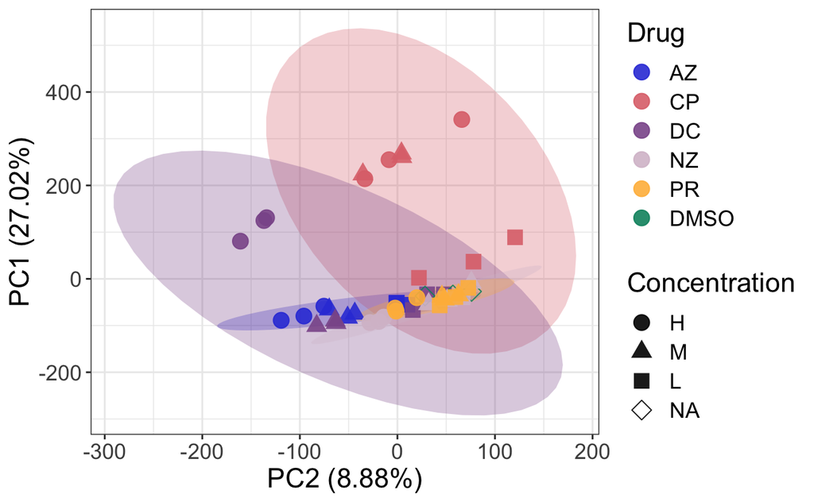

```r
log_exp <- data.frame(imputed_pep$data) %>%
    mutate_all(., funs(log2(.)))
colnames(log_exp) = colnames(imputed_pep$data)
pca<- prcomp(log_exp %>% t(), center=T, scale=F)
sampleVals<-data.frame(pca$x)
exprVals<-data.frame(pca$rotation)
PoV <- (pca$sdev^2/sum(pca$sdev^2))*100

coords<-data.frame(sampleVals, Drug = metadata$Drug,
                   samplename = rownames(sampleVals),
                   Concentration = metadata$Conc) %>%
  mutate(Drug = case_when(Drug == "NC" ~ "DMSO",
                          TRUE ~ Drug),
         Concentration = case_when(Concentration == "1D" ~ "NA",
                                   TRUE ~ Concentration))
coords$Concentration <- factor(coords$Concentration, levels = c("H", "M", "L", "NA"))
coords$Drug <- factor(coords$Drug, levels = c("AZ", "CP", "DC", "NZ", "PR", "DMSO"))

numPCs <- 1:length(PoV)
for (i in 1:length(PoV)) {
    percent <- paste0("(", round(PoV[i],2), "%)")
    name <- paste0("PC", i, "per")
    assign(name, percent)
}

## easy and quick PCA function for manual colour and shape
quick_pca_ellipse <- function(coords_df, x_PC, y_PC, shape, fill){
    yaxis <- y_PC
    xaxis <- x_PC
    yperc <- paste0("(", round(PoV[yaxis %>% as.numeric()] ,2), "%)")
    xperc <- paste0("(", round(PoV[xaxis %>% as.numeric()] ,2), "%)")
    yaxislabel <- paste0("PC", yaxis, " ", yperc)
    xaxislabel <- paste0("PC", xaxis, " ", xperc)
    pca_plot <- ggplot(coords, aes_string(x = paste0('PC', xaxis), y = paste0('PC', yaxis))) +
    stat_ellipse(data = coords %>% filter(Drug!="DMSO"), aes(group=Drug, fill=Drug), type="norm", geom="polygon", alpha=0.3, show.guide=F) +
      guides(fill=F) +
      geom_point(size=4, aes_string(shape = shape, color = fill), alpha=0.9) +
        scale_color_manual(values=c("#3444DA",  "#DF737A", "#8C5999", "#D7C0D0", "#FFBA49",
                                     "#00916E")) +
      scale_fill_manual(values=c("#3444DA",  "#DF737A", "#8C5999", "#D7C0D0", "#FFBA49")) +
      scale_shape_manual(values=c(19, 17, 15, 23))+
        scale_x_continuous(name=xaxislabel) +
        scale_y_continuous(name=yaxislabel) +
        theme_bw() +
        theme(legend.position = "right", text=element_text(size=16))
    return(pca_plot)
}
(pc12 <- quick_pca_ellipse(coords_df = coords, x_PC = 2, y_PC = 1, shape = "Concentration", fill = "Drug"))
```

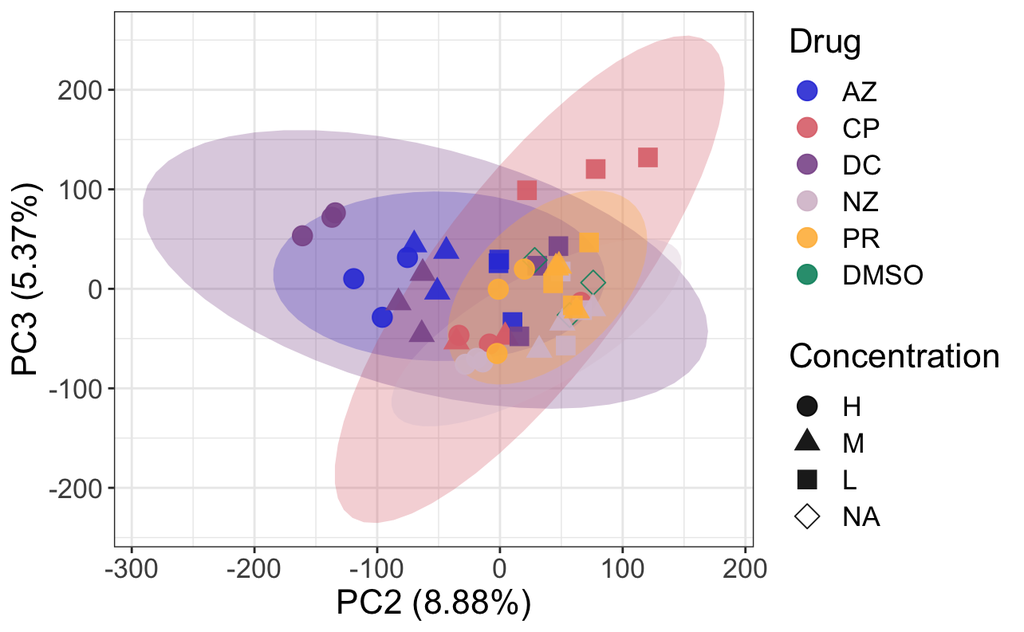

```r
(pc23 <- quick_pca_ellipse(coords_df = coords, x_PC = 2, y_PC = 3, shape = "Concentration", fill = "Drug"))
```

```r
#ggsave(filename = "../../4.mSystems/2.revisionv2/figs/dataset2_pc12_ellipse.pdf", pc12, width = 8, height = 6, units = "in")
#ggsave(filename = "../../4.mSystems/2.revisionv2/figs/dataset2_pc12_ellipse.eps", pc12, width = 8, height = 6, units = "in")

#write.csv(log_exp, here::here("data","Dataset2", "dataset2-msms_log2_normalized.csv"), quote=F, row.names = T)
```

## UMAP and file writing

We will also visualize the treatments using UMAP to check as a quick QC check before MPC-MS1.

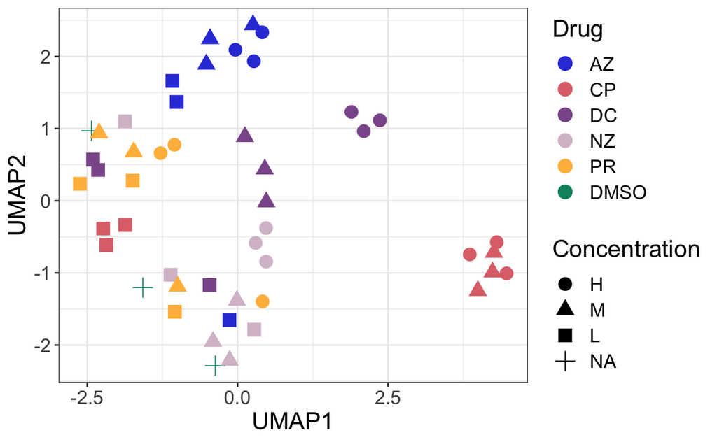

```r
ms1_umap <- umap(log_exp %>% as.matrix %>% t(), n_components=2, random_state=2248)
coords_umap<-data.frame(ms1_umap$layout, Drug = metadata$Drug,
                   samplename = rownames(sampleVals),
                   Concentration = metadata$Conc) %>%
  mutate(Drug = case_when(Drug == "NC" ~ "DMSO",
                          TRUE ~ Drug),
         Concentration = case_when(Concentration == "1D" ~ "NA",
                                   TRUE ~ Concentration))
coords_umap$Concentration <- factor(coords_umap$Concentration, levels = c("H", "M", "L", "NA"))
coords_umap$Drug <- factor(coords_umap$Drug, levels = c("AZ", "CP", "DC", "NZ", "PR", "DMSO"))

#UMAP plot
(umap_drug<- ggplot(coords_umap, aes(x = X1, y = X2)) +
        geom_point(size=4, aes(shape = Concentration, color = Drug)) +
         scale_color_manual(values=c("#3444DA",  "#DF737A", "#8C5999", "#D7C0D0", "#FFBA49",
                                     "#00916E")) +
        scale_x_continuous(name="UMAP1") +
        scale_y_continuous(name="UMAP2") +
        theme_bw() +
        theme(legend.position = "right", text=element_text(size=16)))
```

```r
#ggsave(filename = "../../4.mSystems/2.revisionv2/figs/dataset2_umap.pdf", umap_drug, width = 8, height = 6, units = "in")
#ggsave(filename = "../../4.mSystems/2.revisionv2/figs/dataset2_umap.eps", umap_drug, width = 8, height = 6, units = "in")
```

## Clustering

Note: we are using [precise-db’s](https://github.com/SBRG/precise-db) ICA implementation. Clustering can be completed the following scripts provided in `bin/`. The ICA implementation of precise-db requires a conda environment which can be accessed using `conda activate precise-db`.

Once ICA has completed it’s run, you will find `S.csv` (and other relevent files) in your chosen output directory. We will be clustering this matrix using `kmed_clustering.py` This script was written considering the newest versions of used packages, thus, `kmed_clustering.py` also has it’s own `conda` environment named `k-med`.

The following should be run in your terminal and requires `conda` and `python`.

```r
## THIS IS A SHELL SCRIPT
## It is best to run this in it's own terminal window because of RStudio's memory limitations
cd ./bin
# You will need to create a specific conda environment for ICA.
# Uncomment the code below to create the environment
# conda env create -f environment.yml
conda activate precise-db
## script for robust ICA matrix decomposition
## Update -n to as many threads you have available; ideally at least 6
## However this will run on a laptop with fewer cores, it just may take longer
sh run_ica.sh -i 100 -t 1e-8 -n 6 -o ../../data/msms/ -l ../../data/msms/ica.log ../../data/msms/ms2_fc.csv
conda deactivate

# to create the correct conda environment for clustering
#conda env create -f k-med_env.yml
# This k-medoid clustering relies on newer modules than the ica implementation
conda activate k-med
./kmed_clutering.py -s ../data/msms/S.csv -d ../data/msms/
conda deactivate
```

## Cluster eigenfeature calculation and clustering visualization

After we use `Python` for clustering our relatively large dataset, let’s calculate summary statistics of each peptide cluster considering the peptide intensity values.

```r
#sil <- read.csv(here::here("data", "msms", "k-med_silhouette.csv"), header=F)
#inertia <- read.csv(here::here("data", "msms", "k-med_inertia.csv"), header=F)
kmedoid_labels <- read.csv(here::here("data", "Dataset2", "k-med_labels.csv"), header=F) %>% as.vector()
imputed_features <- imputed_pep$data
clusterinfopep <- kmedoid_labels %>% data.frame()

max_clust <- kmedoid_labels %>% unique() %>% max()

print(paste("Number of clusters:", max_clust+1))
```

```
[1] "Number of clusters: 48"
```

```r
## creating a list that contains intensities of each peptide cluster
clusters <- list()

## creating a list that contains intensities of each peptide cluster
for (x in 0:max_clust){
    clustername <- paste("Cluster", x)
    y <- kmedoid_labels[which(kmedoid_labels$V1 == x),,drop=F] %>% rownames()
    intensities <- imputed_features[y %>% as.numeric(),] %>% as.data.frame()
    intensities <- intensities %>% mutate(feat_num = y)
    clusters[[clustername]] <- intensities
}
### eigenfactors
### Singular value decomposition for genome-wide expression data processing and modeling
###  https://doi.org/10.1073/pnas.97.18.10101
## https://www.biostars.org/p/299167/
## eigengenes <- svd(X)$v
## We are using PCA
#pca_clusters <- lapply(fc_clusters, function(x) prcomp(x %>% dplyr::select(-feat_num) %>% t(), center=T, scale=F)$x)
# grabbing the first principal component
## We are using PCA
pca_clusters <- lapply(clusters, function(x) prcomp(x %>% dplyr::select(-feat_num) %>% t(), center=T, scale=F)$x)
svd_clusters <- lapply(clusters, function(x) svd(x %>% dplyr::select(-feat_num))$v)
# grabbing the first principal component
svd1_cluster <- lapply(svd_clusters,  "[", , 1)
pc1_cluster <- lapply(pca_clusters,  "[", , 1)
clustereigenfactors_pca <- bind_cols(pc1_cluster) %>% data.frame()
clustereigenfactors_svd <- bind_cols(svd1_cluster) %>% data.frame()
```

After calculating eigenfactors for each peptide cluster, we correlate each eigenfactor to each sample’s drug treatment.

```r
metadata <- metadata %>% mutate(drug_conc = paste0(Drug, "-", Conc),
                                  drug_conc = case_when(drug_conc == 'NC-1D' ~ 'DMSO',
                                                        TRUE ~ drug_conc ))

## make a factored dataframe of the compounds
datTraits <- data.frame(compounds= as.factor(metadata$drug_conc))
rownames(datTraits) <- metadata$Name
traits <- model.matrix(~ ., data=datTraits,
                       contrasts.arg = lapply(datTraits, contrasts, contrasts=FALSE))
traits <- traits[,-1] ##removing intercept
moduleTraitCor_pca <- stats::cor(clustereigenfactors_pca, traits, method = "s")
moduleTraitCor_svd <- stats::cor(clustereigenfactors_svd, traits, method = "s")
colnames(moduleTraitCor_pca) <- colnames(moduleTraitCor_pca) %>% substr(., 10, nchar(colnames(moduleTraitCor_pca)))
colnames(moduleTraitCor_svd) <- colnames(moduleTraitCor_svd) %>% substr(., 10, nchar(colnames(moduleTraitCor_svd)))
```

We cluster drug treatments using correlation distance. To identify robust clusters, we perform 1000 bootstrap iterations.

```r
#module_clust_pca <- hclust(as.dist(1-cor(t(moduleTraitCor_pca), method="pearson")), method="average")
#drug_clust_pca <- hclust(as.dist(1-cor(moduleTraitCor_pca, method="pearson")), method="average")
#drug_clust_boot_pca <- pvclust(moduleTraitCor_pca, method.hclust="average",
#                           method.dist="correlation", nboot=1000,
#                           iseed=2248)
#
### Visualize the bootstrap clusters
#clust_boot_pca <- as.dendrogram(drug_clust_boot_pca)
#drug_clust_boot_pca %>% as.dendrogram() %>% plot(main = "test")
#drug_clust_boot_pca %>% text
#drug_clust_boot_pca %>% pvrect(alpha=0.9, pv="au")
#
### Function for quick silhouette score calculation
#
#new_palette <- colorRampPalette(c("#70A9A1", "white", "#FF9633"))(n=120)
#
### metadata for clustr heatmap
#cor_meta_pca <- data.frame(treatment = colnames(moduleTraitCor_pca)) %>%
#    mutate(drug_col = case_when(str_detect(treatment, 'AZ') ~ '#3444DA',
#                                str_detect(treatment, 'CP') ~ '#DF737A',
#                                str_detect(treatment, 'DC') ~ '#8C5999',
#                                str_detect(treatment, 'NZ') ~ '#D7C0D0',
#                                str_detect(treatment, 'PR') ~ '#FFBA49'
#                                )) %>%
#    mutate(conc_col = case_when(str_detect(treatment, '-H') ~ '#08090A',
#                                str_detect(treatment, '-M') ~ '#96999C',
#                                str_detect(treatment, '-L') ~ '#EAEBEB'))
#range(moduleTraitCor_pca)
### Uncomment to save PDF of heatmap
#pdf(here::here("figs", "msms_kmed_hm_pca.pdf"), width=9, height=6)
#par(xpd = TRUE) # allows legend to be outside "official" plotting lines
#coords2 <- list(x=0, y=0.95)
#heatmap.2(moduleTraitCor_pca,
#          notecol="black",      # change font color of cell labels to black
#          density.info="none",  # turns off density plot inside color legend
#          trace="none",         # turns off trace lines inside the heat map
#          margins =c(5,0),      # widens margins around plot
#          col=new_palette,      #
#          breaks=seq(-0.6,0.6,0.01),    # enable color transition at specified limits
#          dendrogram="col",     # only draw a row dendrogram
#          Colv=as.dendrogram(drug_clust_pca),            # turn off column clustering
#          Rowv=as.dendrogram(module_clust_pca),
#          #ColSideColors = cor_meta$drug_col,
#          ColSideColors = cor_meta_pca$drug_col,
#          labRow = "",
#          key.xlab ="Correlation",
#          key.title = NA,
#          lhei = c(1,4),
#          lwid= c(1,3),
#          cexCol = 1.2,
#          keysize = 1)
#legend(coords2, title = "Drug",legend=c("AZ","CP", "DC", "NZ", "PR"),
#       fill=c("#3444DA",  "#DF737A", "#8C5999", "#D7C0D0", "#FFBA49"), cex=0.8, box.lty=0)
## Uncomment if you are saving to file
##dev.off()
```

Now, let’s look at *SVD-derived* eigenfatures (this is the more common way of calculating an eigenfeature).

```r
module_clust_svd <- hclust(as.dist(1-cor(t(moduleTraitCor_svd), method="pearson")), method="average")
drug_clust_svd <- hclust(as.dist(1-cor(moduleTraitCor_svd, method="pearson")), method="average")
drug_clust_boot_svd <- pvclust(moduleTraitCor_svd, method.hclust="average",
                           method.dist="correlation", nboot=1000,
                           iseed=2248)
```

```
Bootstrap (r = 0.5)... Done.
Bootstrap (r = 0.58)... Done.
Bootstrap (r = 0.69)... Done.
Bootstrap (r = 0.79)... Done.
Bootstrap (r = 0.9)... Done.
Bootstrap (r = 1.0)... Done.
Bootstrap (r = 1.08)... Done.
Bootstrap (r = 1.19)... Done.
Bootstrap (r = 1.29)... Done.
Bootstrap (r = 1.4)... Done.
```

Let’s save the clustering output so that we can compare to the MS1 results.

```r
#msms_moduleTraitCor_pca <- moduleTraitCor_pca
#msms_drugclustboot_pca <- drug_clust_boot_pca
#msms_drugclust_pca <- drug_clust_pca
msms_moduleTraitCor_svd <- moduleTraitCor_svd
msms_drugclustboot_svd <- drug_clust_boot_svd
msms_drugclust_svd <- drug_clust_svd
# Uncomment to save the RData file
save(#msms_moduleTraitCor_pca, msms_drugclust_pca, msms_drugclustboot_pca,
     msms_moduleTraitCor_svd, msms_drugclust_svd, msms_drugclustboot_svd,
     file=here::here("data", "Dataset2", "dataset2-msms_dedro.RData"))
```